# AST-Guided Chain-of-Thought Prompting: Statistical Analysis

Alberto Melo

December, 6, 2025

# Overview

In this report we describe the results of our statistical analysis comparing **AST-Guided Chain-of-Thought (CoT) Prompting** vs. **baseline prompting** to generate secure code. We examined the number of detected vulnerabilities for two large language models (Claude and GPT) using three different detection tools (AST Parser, Bandit and Semgrep).

**Research Design:** 2 × 2 Factorial Design

- **First Independent Variable:** Model (GPT vs Claude)
- **Second Independent Variable:** Prompt type (AST-guided CoT vs Baseline CoT)
- **First Dependent Variable:** Number of vulnerabilities found
- **Second Dependent Variable:** Density of vulnerabilities per KLOC.

```r
knitr::kable(table(data$model, data$prompt_type),
             caption = "Sample Sizes per Condition")
```

Sample Sizes per Condition

|  | Baseline | AST-Guided |
| --- | --- | --- |
| Claude | 121 | 121 |
| GPT | 121 | 121 |

# Descriptive Statistics

## Overall Summary

```r
overall_stats <- data.frame(
  Metric = c("Total Vulnerabilities", "Vulnerability Density (per KLOC)", "Lines of Code"),
  N = rep(nrow(data), 3),
  Mean = round(c(mean(data$total_vuln), mean(data$vuln_density), mean(data$loc)), 2),
  SD = round(c(sd(data$total_vuln), sd(data$vuln_density), sd(data$loc)), 2),
  Median = c(median(data$total_vuln), round(median(data$vuln_density), 2), median(data$loc)),
  Min = c(min(data$total_vuln), round(min(data$vuln_density), 2), min(data$loc)),
  Max = round(c(max(data$total_vuln), max(data$vuln_density), max(data$loc)), 2)
)
knitr::kable(overall_stats, caption = "Overall Descriptive Statistics")
```

Overall Descriptive Statistics

| Metric | N | Mean | SD | Median | Min | Max |
| --- | --- | --- | --- | --- | --- | --- |
| Total Vulnerabilities | 484 | 1.00 | 1.44 | 0 | 0 | 9.00 |
| Vulnerability Density (per KLOC) | 484 | 37.16 | 56.30 | 0 | 0 | 357.14 |
| Lines of Code | 484 | 33.81 | 25.09 | 26 | 5 | 164.00 |

## Distribution of Vulnerability Counts

Below is the histogram showing the number of vulnerabilities in each sample.

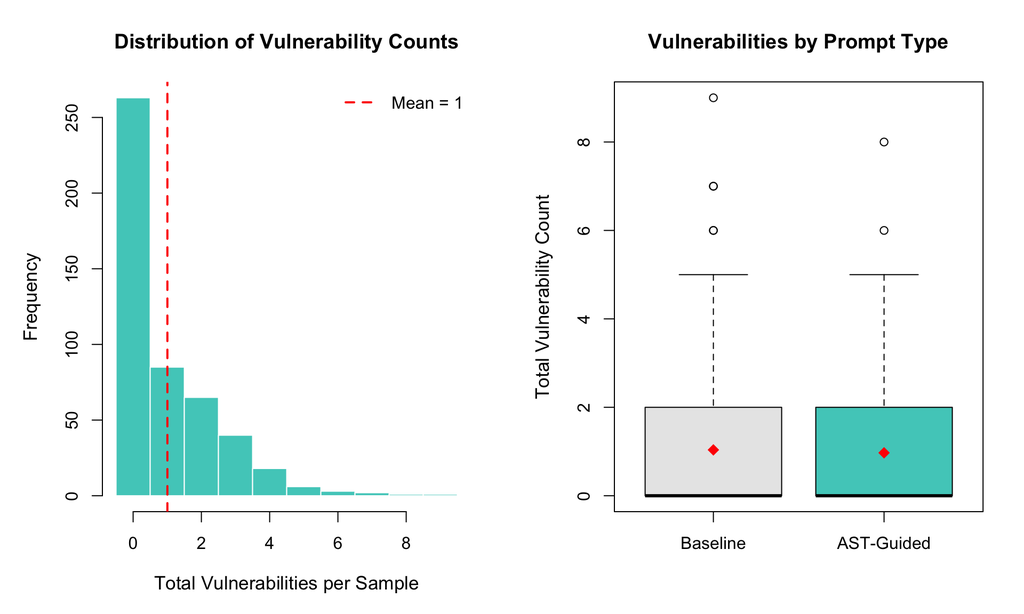

The majority of samples have no vulnerabilities, while the right skewness of the tail indicates that most samples have no vulnerabilities, however there is some variability in this regard.

```r
par(mfrow = c(1, 2), mar = c(5, 5, 4, 2))

vuln_min <- floor(min(data$total_vuln, na.rm = TRUE)) - 0.5
vuln_max <- ceiling(max(data$total_vuln, na.rm = TRUE)) + 0.5
hist_breaks <- seq(vuln_min, vuln_max, by = 1)

hist(data$total_vuln, breaks = hist_breaks,
     col = col_ast, border = "white",
     main = "Distribution of Vulnerability Counts",
     xlab = "Total Vulnerabilities per Sample",
     ylab = "Frequency",
     cex.lab = 1.1, cex.main = 1.2)

abline(v = mean(data$total_vuln, na.rm = TRUE), col = "red", lwd = 2, lty = 2)
legend("topright", legend = paste("Mean =", round(mean(data$total_vuln, na.rm = TRUE), 2)),
       col = "red", lty = 2, lwd = 2, bty = "n")

boxplot(total_vuln ~ prompt_type, data = data,
        col = c(col_baseline, col_ast),
        main = "Vulnerabilities by Prompt Type",
        ylab = "Total Vulnerability Count",
        xlab = "",
        cex.lab = 1.1, cex.main = 1.2)

means_prompt <- c(mean(baseline_vuln, na.rm = TRUE), mean(ast_vuln, na.rm = TRUE))
points(1:2, means_prompt, pch = 18, col = "red", cex = 1.5)
```

```r
par(mfrow = c(1, 1))
```

## By Condition

Box plots are shown to demonstrate the distribution of vulnerability counts for each condition in our experiments. Group mean values were identified using red diamonds on the box plots.

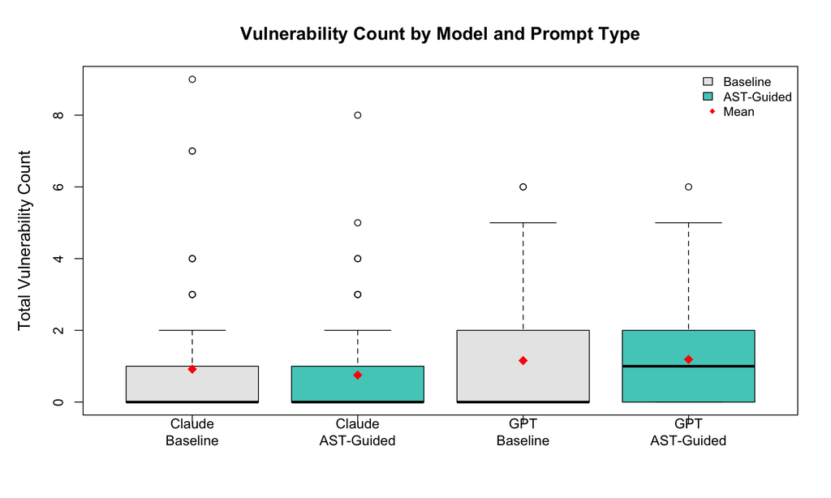

Claude showed an obvious drop in vulnerability (an 18% drop) when it was prompted by AST-Guided prompts.

```r
par(mar = c(5, 5, 4, 2))

boxplot(total_vuln ~ prompt_type + model, data = data,
        col = c(col_baseline, col_ast, col_baseline, col_ast),
        names = c("Claude\nBaseline", "Claude\nAST-Guided", "GPT\nBaseline", "GPT\nAST-Guided"),
        ylab = "Total Vulnerability Count",
        xlab = "",
        main = "Vulnerability Count by Model and Prompt Type",
        cex.lab = 1.2, cex.axis = 1.0, cex.main = 1.3,
        outline = TRUE)

means_box <- c(claude_base_mean, claude_ast_mean, gpt_base_mean, gpt_ast_mean)
points(1:4, means_box, pch = 18, col = "red", cex = 1.5)

legend("topright", legend = c("Baseline", "AST-Guided", "Mean"),
       fill = c(col_baseline, col_ast, NA), pch = c(NA, NA, 18),
       col = c(NA, NA, "red"), border = c("black", "black", NA),
       bty = "n", cex = 0.9)
```

```r
condition_stats <- data.frame(
  Model = c("Claude", "Claude", "GPT", "GPT"),
  Prompt = c("Baseline", "AST-Guided", "Baseline", "AST-Guided"),
  Mean = round(c(claude_base_mean, claude_ast_mean, gpt_base_mean, gpt_ast_mean), 3),
  SD = round(c(sd(claude_base_vuln), sd(claude_ast_vuln), sd(gpt_base_vuln), sd(gpt_ast_vuln)), 3),
  n = c(length(claude_base_vuln), length(claude_ast_vuln), length(gpt_base_vuln), length(gpt_ast_vuln))
)
knitr::kable(condition_stats, caption = "Descriptive Statistics by Condition")
```

Descriptive Statistics by Condition

| Model | Prompt | Mean | SD | n |
| --- | --- | --- | --- | --- |
| Claude | Baseline | 0.917 | 1.520 | 121 |
| Claude | AST-Guided | 0.752 | 1.247 | 121 |
| GPT | Baseline | 1.157 | 1.506 | 121 |
| GPT | AST-Guided | 1.190 | 1.457 | 121 |

The bar chart shows the mean count of vulnerabilities for each condition compared to the standard errors.

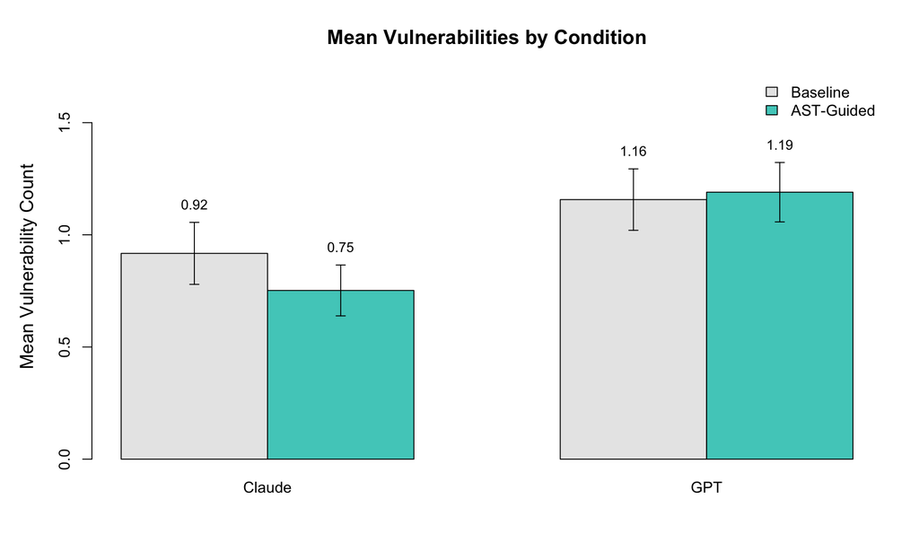

Claude has an 18% reduction in number of vulnerabilities than GPT shows a slight increase.

```r
par(mar = c(5, 5, 4, 2))

bar_data <- matrix(c(claude_base_mean, claude_ast_mean, gpt_base_mean, gpt_ast_mean),
                   nrow = 2, dimnames = list(c("Baseline", "AST-Guided"), c("Claude", "GPT")))
means_vec <- c(claude_base_mean, claude_ast_mean, gpt_base_mean, gpt_ast_mean)
ses <- c(claude_base_se, claude_ast_se, gpt_base_se, gpt_ast_se)

bp <- barplot(bar_data, beside = TRUE, col = c(col_baseline, col_ast),
              ylim = c(0, max(means_vec + ses) * 1.3),
              ylab = "Mean Vulnerability Count",
              main = "Mean Vulnerabilities by Condition",
              cex.lab = 1.2, cex.axis = 1.0, cex.main = 1.3,
              legend.text = c("Baseline", "AST-Guided"),
              args.legend = list(x = "topright", bty = "n"))

arrows(bp, means_vec - ses, bp, means_vec + ses, angle = 90, code = 3, length = 0.05)
text(bp, means_vec + ses + 0.08, labels = round(means_vec, 2), cex = 0.9)
```

## Vulnerabilities by Detection Tool

Three static analysis tools were employed in order to identify vulnerabilities: an ast parser, bandit, and semgrep.

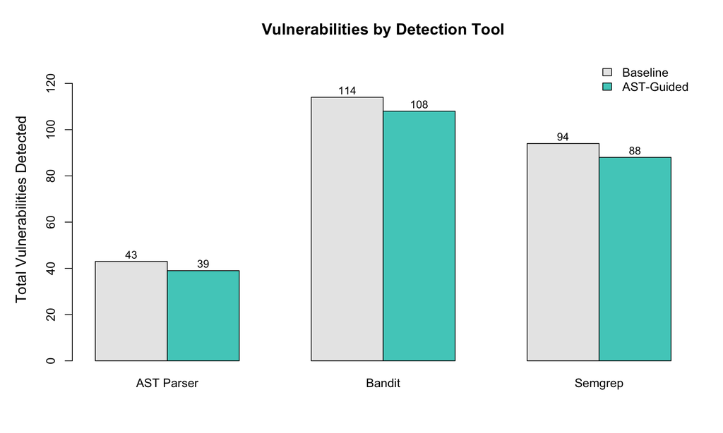

The total number of vulnerabilities identified by each tool for each condition in which a prompt was applied.

```r
par(mar = c(5, 5, 4, 2))

tool_baseline <- c(
  sum(data$vuln_ast[data$prompt_type == "Baseline"]),
  sum(data$vuln_bandit[data$prompt_type == "Baseline"]),
  sum(data$vuln_semgrep[data$prompt_type == "Baseline"])
)
tool_ast <- c(
  sum(data$vuln_ast[data$prompt_type == "AST-Guided"]),
  sum(data$vuln_bandit[data$prompt_type == "AST-Guided"]),
  sum(data$vuln_semgrep[data$prompt_type == "AST-Guided"])
)

tool_matrix <- matrix(c(tool_baseline, tool_ast), nrow = 2, byrow = TRUE,
                      dimnames = list(c("Baseline", "AST-Guided"),
                                      c("AST Parser", "Bandit", "Semgrep")))

tool_counts <- c(tool_baseline[1], tool_ast[1], tool_baseline[2], tool_ast[2], tool_baseline[3], tool_ast[3])

bp3 <- barplot(tool_matrix, beside = TRUE, col = c(col_baseline, col_ast),
               ylim = c(0, max(tool_counts) * 1.15),
               ylab = "Total Vulnerabilities Detected",
               main = "Vulnerabilities by Detection Tool",
               cex.lab = 1.2, cex.axis = 1.0, cex.main = 1.3,
               legend.text = c("Baseline", "AST-Guided"),
               args.legend = list(x = "topright", bty = "n"))

text(bp3, tool_counts + 3, labels = tool_counts, cex = 0.9)
```

```r
tool_stats <- data.frame(
  Tool = c("AST Parser", "Bandit", "Semgrep", "Total"),
  Baseline = c(tool_baseline, sum(tool_baseline)),
  AST_Guided = c(tool_ast, sum(tool_ast)),
  Difference = c(tool_baseline - tool_ast, sum(tool_baseline) - sum(tool_ast)),
  Percent_Change = paste0(round((c(tool_baseline, sum(tool_baseline)) - c(tool_ast, sum(tool_ast))) /
                                  c(tool_baseline, sum(tool_baseline)) * 100, 1), "%")
)
knitr::kable(tool_stats, caption = "Vulnerability Counts by Detection Tool",
             col.names = c("Tool", "Baseline", "AST-Guided", "Difference", "% Reduction"))
```

Vulnerability Counts by Detection Tool

| Tool | Baseline | AST-Guided | Difference | % Reduction |
| --- | --- | --- | --- | --- |
| AST Parser | 43 | 39 | 4 | 9.3% |
| Bandit | 114 | 108 | 6 | 5.3% |
| Semgrep | 94 | 88 | 6 | 6.4% |
| Total | 251 | 235 | 16 | 6.4% |

# Prerequisite: Assumption Testing

Prior to performing any parametric tests it is imperative to check if the data conforms with all of the necessary assumptions for those tests.

## Normality Testing (Shapiro-Wilk)

The shapiro-wilk test assesses the extent to which the data exhibits normality (i.e., does the data follow a normal distribution).

- **H₀:** Data is normally distributed
- **H₁:** Data is NOT normally distributed
- **α = 0.05**

```r
sw_overall <- shapiro.test(data$total_vuln)

normality_results <- data.frame(
  Condition = c("Overall", "Claude + Baseline", "Claude + AST-Guided",
                "GPT + Baseline", "GPT + AST-Guided"),
  W = round(c(
    sw_overall$statistic,
    shapiro.test(claude_base_vuln)$statistic,
    shapiro.test(claude_ast_vuln)$statistic,
    shapiro.test(gpt_base_vuln)$statistic,
    shapiro.test(gpt_ast_vuln)$statistic
  ), 4),
  p_value = format(c(
    sw_overall$p.value,
    shapiro.test(claude_base_vuln)$p.value,
    shapiro.test(claude_ast_vuln)$p.value,
    shapiro.test(gpt_base_vuln)$p.value,
    shapiro.test(gpt_ast_vuln)$p.value
  ), scientific = TRUE, digits = 3),
  Conclusion = rep("NOT normal (p < .05)", 5)
)

knitr::kable(normality_results, caption = "Shapiro-Wilk Normality Test Results")
```

Shapiro-Wilk Normality Test Results

| Condition | W | p_value | Conclusion |
| --- | --- | --- | --- |
| Overall | 0.7270 | 2.16e-27 | NOT normal (p < .05) |
| Claude + Baseline | 0.6441 | 1.05e-15 | NOT normal (p < .05) |
| Claude + AST-Guided | 0.6457 | 1.14e-15 | NOT normal (p < .05) |
| GPT + Baseline | 0.7713 | 1.89e-12 | NOT normal (p < .05) |
| GPT + AST-Guided | 0.7948 | 1.03e-11 | NOT normal (p < .05) |

**Interpretation:** Given that all of the assumptions violated the normality assumption (p < .05) this was to be expected due to a floor effect in the data; therefore nonparametric testing will be performed along with parametric testing as well for sensitivity analysis.

## Homogeneity of Variance (Levene’s Test)

The Levene’s test determines if there is an equality of variance between different groupings.

- **H₀:** Variances are equal across groups
- **H₁:** Variances are NOT equal across groups
- **α = 0.05**

```r
levene_result <- levene_test(data$total_vuln, interaction(data$model, data$prompt_type))

cat(paste0("F(", levene_result$df1, ", ", levene_result$df2, ") = ",
           round(levene_result$F_value, 4), ", p = ", round(levene_result$p_value, 4)))
```

```
## F(3, 480) = 2.9541, p = 0.0322
```

**Interpretation:** The results from the Levene’s Test indicate if variance in the vulnerability count is equal or unequal across the different model types/prompt types.

# Analysis 1: Two-Way Factorial ANOVA

**Research Question:** Are Model Type and Prompt Type statistically significant for a difference in vulnerability counts? Is there a statistically significant interaction effect between Model Type and Prompt Type on a vulnerability count?

**Design:** 2 (Claude vs. GPT Model Types) x 2 (Baseline vs. AST-Guided Prompt Types)

**Hypotheses:**

- H₁ₐ : Effect of Model – The main effect of the two models (Claude and GPT) show a difference in the total count of their vulnerabilities.
- H₁ᵦ : Effect of Prompt – The main effect of the two prompts (AST-Guided and Baseline) are different from each other regarding the total count of vulnerabilities.
- H₁꜀ : Interaction effect – The effect of prompt type varies based upon the type of model.

```r
anova_model <- aov(total_vuln ~ model * prompt_type, data = data)
anova_summary <- summary(anova_model)

print(anova_summary)
```

```
##                    Df Sum Sq Mean Sq F value  Pr(>F)
## model               1   13.9  13.893   6.733 0.00975 **
## prompt_type         1    0.5   0.529   0.256 0.61287
## model:prompt_type   1    1.2   1.190   0.577 0.44795
## Residuals         480  990.4   2.063
## ---
## Signif. codes:  0 '***' 0.001 '**' 0.01 '*' 0.05 '.' 0.1 ' ' 1
```

```r
ss <- anova_summary[[1]]$`Sum Sq`
ss_total <- sum(ss)
eta_sq <- ss / ss_total

effect_sizes <- data.frame(
  Effect = c("Model", "Prompt Type", "Model x Prompt", "Residual"),
  Sum_Sq = round(ss, 2),
  Eta_Squared = round(eta_sq, 4),
  Interpretation = c(
    ifelse(eta_sq[1] < 0.01, "Negligible", ifelse(eta_sq[1] < 0.06, "Small", ifelse(eta_sq[1] < 0.14, "Medium", "Large"))),
    ifelse(eta_sq[2] < 0.01, "Negligible", ifelse(eta_sq[2] < 0.06, "Small", ifelse(eta_sq[2] < 0.14, "Medium", "Large"))),
    ifelse(eta_sq[3] < 0.01, "Negligible", ifelse(eta_sq[3] < 0.06, "Small", ifelse(eta_sq[3] < 0.14, "Medium", "Large"))),
    "-"
  )
)

knitr::kable(effect_sizes, caption = "Effect Sizes (Eta-Squared)")
```

Effect Sizes (Eta-Squared)

| Effect | Sum_Sq | Eta_Squared | Interpretation |
| --- | --- | --- | --- |
| Model | 13.89 | 0.0138 | Small |
| Prompt Type | 0.53 | 0.0005 | Negligible |
| Model x Prompt | 1.19 | 0.0012 | Negligible |
| Residual | 990.38 | 0.9845 | - |

Interaction plot displays how the impact of the prompt type is different for each model.

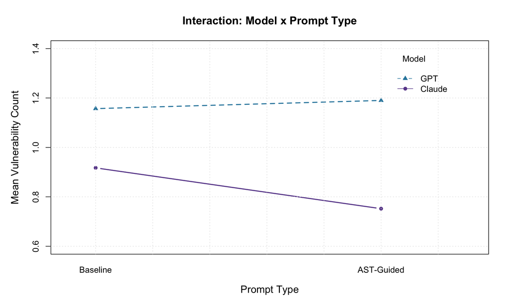

Claude has a larger decrease in the number of vulnerabilities when using AST-Guided prompts than GPT which indicates that AST-Guided was less effective for GPT

```r
par(mar = c(5, 5, 4, 2))

interaction.plot(data$prompt_type, data$model, data$total_vuln,
                 type = "b", pch = c(16, 17), lty = c(1, 2),
                 col = c(col_claude, col_gpt), lwd = 2,
                 ylab = "Mean Vulnerability Count",
                 xlab = "Prompt Type",
                 main = "Interaction: Model x Prompt Type",
                 trace.label = "Model",
                 cex.lab = 1.2, cex.axis = 1.0, cex.main = 1.3,
                 ylim = c(0.6, 1.4))

grid(col = "gray90")
```

**Interpretation:** The Interaction Plot indicates that Claude’s response to AST-Guided Prompting is greater than GPT’s Response to AST-Guided Prompting.

# Analysis 2: Independent Samples t-test

**Research Question:** Is there a statistically significant reduction in Vulnerability Counts from Baseline Prompting when using AST-Guided Prompting.

**Hypotheses:**

- H₀: μ(AST-Guided) = μ(Baseline)
- H₁: μ(AST-Guided) ≠ μ(Baseline)
- α = 0.05

```r
ttest_result <- t.test(ast_vuln, baseline_vuln, var.equal = FALSE)
cohens_d_result <- cohens_d(ast_vuln, baseline_vuln)

ttest_table <- data.frame(
  Group = c("AST-Guided", "Baseline"),
  Mean = round(c(mean(ast_vuln), mean(baseline_vuln)), 3),
  SD = round(c(sd(ast_vuln), sd(baseline_vuln)), 3),
  n = c(length(ast_vuln), length(baseline_vuln))
)

knitr::kable(ttest_table, caption = "Group Statistics")
```

Group Statistics

| Group | Mean | SD | n |
| --- | --- | --- | --- |
| AST-Guided | 0.971 | 1.371 | 242 |
| Baseline | 1.037 | 1.514 | 242 |

```r
cat(paste0("\nWelch's t-test: t(", round(ttest_result$parameter, 2), ") = ",
           round(ttest_result$statistic, 4), ", p = ", round(ttest_result$p.value, 4)))
```

```
##
## Welch's t-test: t(477.29) = -0.5035, p = 0.6148
```

```r
cat(paste0("\n95% CI: [", round(ttest_result$conf.int[1], 4), ", ",
           round(ttest_result$conf.int[2], 4), "]"))
```

```
##
## 95% CI: [-0.3241, 0.1919]
```

```r
cat(paste0("\nCohen's d = ", round(cohens_d_result$estimate, 4), " (", cohens_d_result$magnitude, ")"))
```

```
##
## Cohen's d = -0.0458 (negligible)
```

# Analysis 3: Mann-Whitney U Test (Non-parametric)

**Rationale:** The violation of normality assumptions for the data is the reason why the Mann-Whitney U Test is used as a non-parametric alternative to provide a robust test.

**Hypotheses:**

- H₀: The distributions of vulnerabilities are equal between groups
- H₁: The distributions differ between groups
- α = 0.05

```r
mw_result <- wilcox.test(ast_vuln, baseline_vuln, exact = FALSE, correct = TRUE)

z_score <- qnorm(mw_result$p.value / 2)
r_effect <- abs(z_score) / sqrt(length(ast_vuln) + length(baseline_vuln))

cat(paste0("Mann-Whitney U: W = ", mw_result$statistic, ", p = ", round(mw_result$p.value, 4)))
```

```
## Mann-Whitney U: W = 29081, p = 0.8863
```

```r
cat(paste0("\nEffect size r = ", round(r_effect, 4), " (",
           ifelse(r_effect < 0.1, "negligible", ifelse(r_effect < 0.3, "small",
           ifelse(r_effect < 0.5, "medium", "large"))), ")"))
```

```
##
## Effect size r = 0.0065 (negligible)
```

# Analysis 4: Correlation Analysis

**Research Question:** What are the relationships between various vulnerability detection tools (and) the characteristics of code?

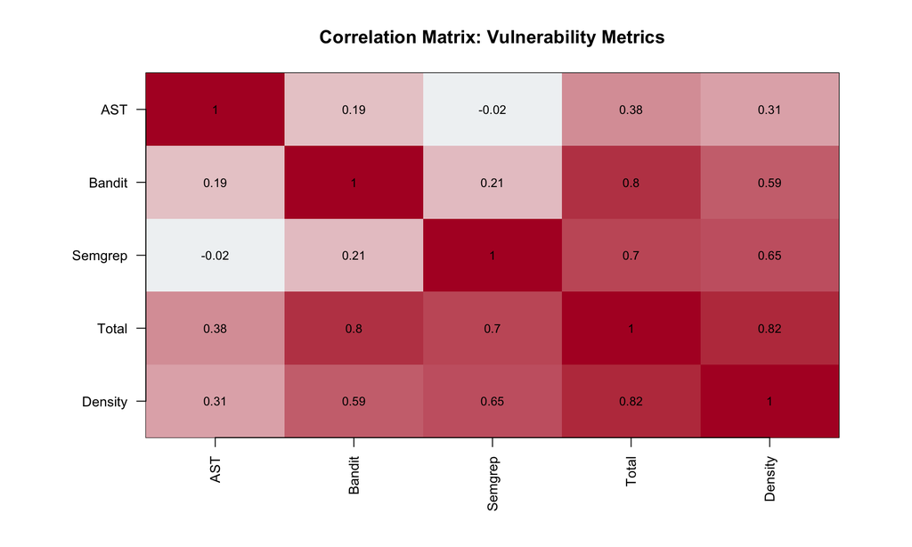

Correlation Heatmap of Vulnerability Metrics. The darker red indicates that there is a higher correlation to each other (of) the positive relationship between the two variables.

```r
par(mar = c(6, 8, 4, 4))

cor_subset <- cor_matrix[c("vuln_ast", "vuln_bandit", "vuln_semgrep", "total_vuln", "vuln_density"),
                         c("vuln_ast", "vuln_bandit", "vuln_semgrep", "total_vuln", "vuln_density")]

n_colors <- 100
colors <- colorRampPalette(c("#2166AC", "#F7F7F7", "#B2182B"))(n_colors)

image(1:5, 1:5, t(cor_subset[5:1, ]), col = colors, zlim = c(-1, 1),
      xaxt = "n", yaxt = "n", xlab = "", ylab = "",
      main = "Correlation Matrix: Vulnerability Metrics")

labels <- c("AST", "Bandit", "Semgrep", "Total", "Density")
axis(1, at = 1:5, labels = labels, las = 2, cex.axis = 0.9)
axis(2, at = 1:5, labels = rev(labels), las = 2, cex.axis = 0.9)

for (i in 1:5) {
  for (j in 1:5) {
    text(i, 6-j, round(cor_subset[j, i], 2), cex = 0.8)
  }
}
```

```r
cor_results <- data.frame(
  Comparison = c("AST Parser vs Bandit", "AST Parser vs Semgrep", "Bandit vs Semgrep",
                 "LOC vs Total Vuln", "LOC vs Vuln Density"),
  r = round(c(
    cor(data$vuln_ast, data$vuln_bandit),
    cor(data$vuln_ast, data$vuln_semgrep),
    cor(data$vuln_bandit, data$vuln_semgrep),
    cor(data$loc, data$total_vuln),
    cor(data$loc, data$vuln_density)
  ), 3),
  p_value = format(c(
    cor.test(data$vuln_ast, data$vuln_bandit)$p.value,
    cor.test(data$vuln_ast, data$vuln_semgrep)$p.value,
    cor.test(data$vuln_bandit, data$vuln_semgrep)$p.value,
    cor.test(data$loc, data$total_vuln)$p.value,
    cor.test(data$loc, data$vuln_density)$p.value
  ), scientific = TRUE, digits = 3),
  Significant = c(
    ifelse(cor.test(data$vuln_ast, data$vuln_bandit)$p.value < 0.05, "*", "ns"),
    ifelse(cor.test(data$vuln_ast, data$vuln_semgrep)$p.value < 0.05, "*", "ns"),
    ifelse(cor.test(data$vuln_bandit, data$vuln_semgrep)$p.value < 0.05, "***", "ns"),
    ifelse(cor.test(data$loc, data$total_vuln)$p.value < 0.05, "*", "ns"),
    ifelse(cor.test(data$loc, data$vuln_density)$p.value < 0.05, "***", "ns")
  )
)

knitr::kable(cor_results, caption = "Key Correlations with Significance Tests")
```

Key Correlations with Significance Tests

| Comparison | r | p_value | Significant |
| --- | --- | --- | --- |
| AST Parser vs Bandit | 0.186 | 4.01e-05 | * |
| AST Parser vs Semgrep | -0.024 | 6.00e-01 | ns |
| Bandit vs Semgrep | 0.211 | 2.96e-06 | *** |
| LOC vs Total Vuln | 0.124 | 6.17e-03 | * |
| LOC vs Vuln Density | -0.179 | 7.43e-05 | *** |

# Analysis 5: Multiple Regression

**Research Question:** How strong is the predictive ability of Model, Prompt Type, and Lines of Code for total number of vulnerabilities?

**Model:** `total_vuln ~ model + prompt_type + loc + model:prompt_type`

```r
reg_model <- lm(total_vuln ~ model + prompt_type + loc + model:prompt_type, data = data)
reg_summary <- summary(reg_model)

# Create clean regression table
reg_table <- data.frame(
  Predictor = c("(Intercept)", "Model (GPT)", "Prompt Type (AST-Guided)",
                "Lines of Code", "Model × Prompt Type"),
  Estimate = round(reg_summary$coefficients[, 1], 4),
  SE = round(reg_summary$coefficients[, 2], 4),
  t = round(reg_summary$coefficients[, 3], 2),
  p = c(
    format.pval(reg_summary$coefficients[1, 4], digits = 3),
    format.pval(reg_summary$coefficients[2, 4], digits = 3),
    format.pval(reg_summary$coefficients[3, 4], digits = 3),
    format.pval(reg_summary$coefficients[4, 4], digits = 3),
    format.pval(reg_summary$coefficients[5, 4], digits = 3)
  )
)

knitr::kable(reg_table, caption = "Regression Coefficients",
             col.names = c("Predictor", "Estimate", "Std. Error", "t", "p"),
             row.names = FALSE)
```

Regression Coefficients

| Predictor | Estimate | Std. Error | t | p |
| --- | --- | --- | --- | --- |
| (Intercept) | 0.2583 | 0.1915 | 1.35 | 0.178 |
| Model (GPT) | 0.5958 | 0.1966 | 3.03 | 0.00257 |
| Prompt Type (AST-Guided) | -0.0936 | 0.1815 | -0.52 | 0.606 |
| Lines of Code | 0.0136 | 0.0029 | 4.62 | 4.85e-06 |
| Model × Prompt Type | 0.1462 | 0.2560 | 0.57 | 0.568 |

```r
cat(paste0("\nModel Fit Statistics:"))
```

```
##
## Model Fit Statistics:
```

```r
cat(paste0("\n  R-squared = ", round(reg_summary$r.squared, 4)))
```

```
##
##   R-squared = 0.0576
```

```r
cat(paste0("\n  Adjusted R-squared = ", round(reg_summary$adj.r.squared, 4)))
```

```
##
##   Adjusted R-squared = 0.0497
```

```r
cat(paste0("\n  F(", reg_summary$fstatistic[2], ", ", reg_summary$fstatistic[3], ") = ",
           round(reg_summary$fstatistic[1], 4),
           ", p = ", format.pval(pf(reg_summary$fstatistic[1], reg_summary$fstatistic[2],
                              reg_summary$fstatistic[3], lower.tail = FALSE), digits = 3)))
```

```
##
##   F(4, 479) = 7.3174, p = 1e-05
```

**Interpretation:**

The full regression model was statistically significant (5.8)%. Key results from the regression model include:

- **Lines of Code (LOC)**: Significant (p < .001). Each increase in LOC results in an expected increase in the number of vulnerabilities of approximately 0.014.
- **Model (GPT vs Claude)**: Significant (p = .003). On average, GPT had approximately 0.60 more vulnerabilities per sample than Claude.
- **Prompt Type (AST-Guided vs Baseline)**: Non-significant (p = .606). AST-Guided prompting was not a statistically significant predictor of the number of vulnerabilities, after accounting for other variables.
- **Interaction (Model × Prompt Type)**: Non-significant (p = .568). There was no statistical difference in how prompt types affected the number of vulnerabilities based on the models used.

# Vulnerability Density Analysis

Vulnerability Density allows for a fair comparison among samples that have varying sizes, by normalizing the number of vulnerabilities per sample to the total number of lines of code in each sample.

**Formula:** Vulnerability Density = (Total Vulnerabilities / Lines of Code) × 1000

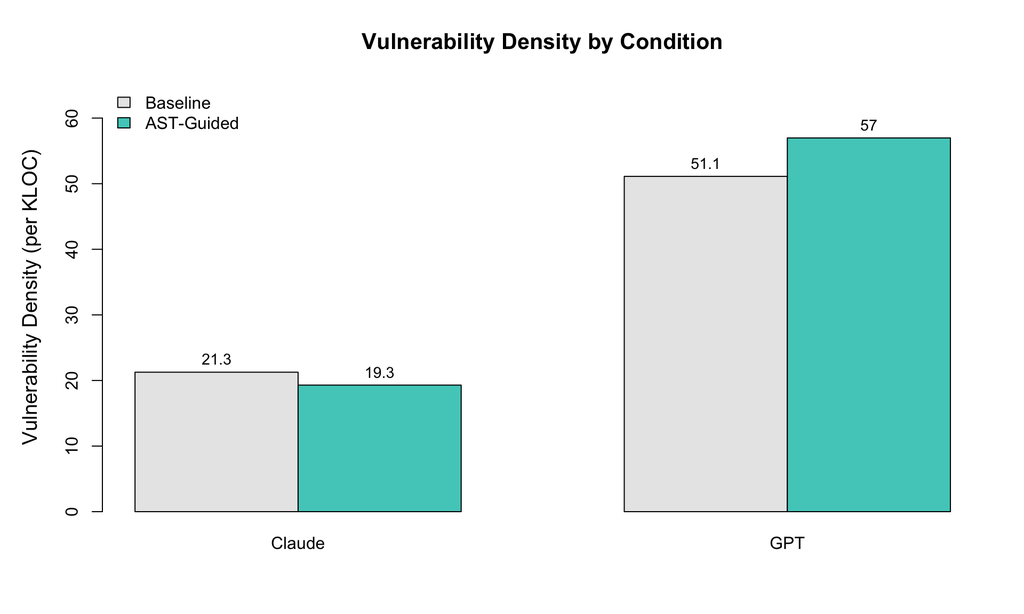

Vulnerability density by condition. Claude shows reduction in vulnerability density with AST-Guided prompting.

```r
par(mar = c(5, 5, 4, 2))

density_data <- matrix(c(claude_base_density, claude_ast_density, gpt_base_density, gpt_ast_density),
                       nrow = 2, dimnames = list(c("Baseline", "AST-Guided"), c("Claude", "GPT")))
density_vec <- c(claude_base_density, claude_ast_density, gpt_base_density, gpt_ast_density)

bp2 <- barplot(density_data, beside = TRUE, col = c(col_baseline, col_ast),
               ylim = c(0, max(density_vec) * 1.15),
               ylab = "Vulnerability Density (per KLOC)",
               main = "Vulnerability Density by Condition",
               cex.lab = 1.2, cex.axis = 1.0, cex.main = 1.3,
               legend.text = c("Baseline", "AST-Guided"),
               args.legend = list(x = "topleft", bty = "n"))

text(bp2, density_vec + 2, labels = round(density_vec, 1), cex = 0.9)
```

```r
density_stats <- data.frame(
  Metric = c("AST-Guided", "Baseline", "Difference", "Percent Reduction"),
  Value = c(
    paste0(round(mean(ast_density), 2), " vulns/KLOC"),
    paste0(round(mean(baseline_density), 2), " vulns/KLOC"),
    paste0(round(mean(baseline_density) - mean(ast_density), 2), " vulns/KLOC"),
    paste0(round((mean(baseline_density) - mean(ast_density)) / mean(baseline_density) * 100, 2), "%")
  )
)

knitr::kable(density_stats, caption = "Vulnerability Density Comparison")
```

Vulnerability Density Comparison

| Metric | Value |
| --- | --- |
| AST-Guided | 38.14 vulns/KLOC |
| Baseline | 36.19 vulns/KLOC |
| Difference | -1.95 vulns/KLOC |
| Percent Reduction | -5.38% |

```r
density_ttest <- t.test(ast_density, baseline_density, var.equal = FALSE)
density_d <- cohens_d(ast_density, baseline_density)

cat(paste0("\nt-test on density: t(", round(density_ttest$parameter, 2), ") = ",
           round(density_ttest$statistic, 4), ", p = ", round(density_ttest$p.value, 4)))
```

```
##
## t-test on density: t(479.2) = 0.38, p = 0.7041
```

```r
cat(paste0("\nCohen's d = ", round(density_d$estimate, 4), " (", density_d$magnitude, ")"))
```

```
##
## Cohen's d = 0.0345 (negligible)
```

# Summary of Findings

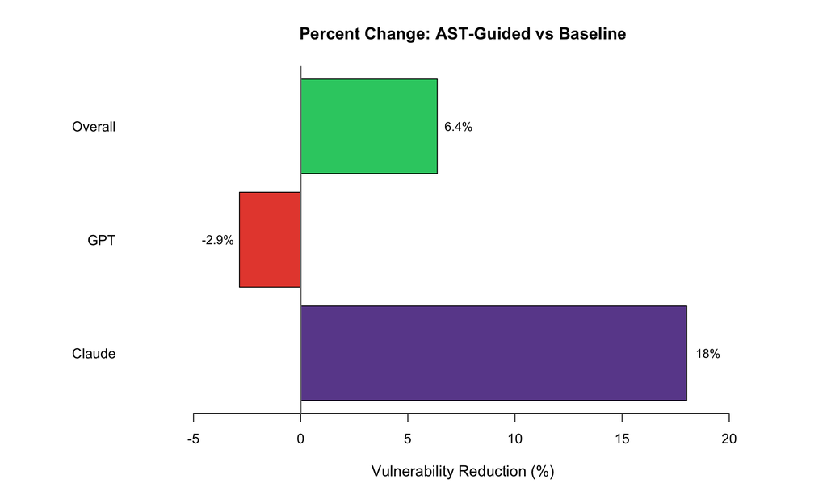

Percentage decrease in the number of identified vulnerabilities due to AST-Guided prompting compared to Baseline.

```r
par(mar = c(5, 8, 4, 2))

reductions <- c(
  (claude_base_mean - claude_ast_mean) / claude_base_mean * 100,
  (gpt_base_mean - gpt_ast_mean) / gpt_base_mean * 100,
  (mean(baseline_vuln) - mean(ast_vuln)) / mean(baseline_vuln) * 100
)

bar_colors <- c(col_claude, col_gpt, "#2ECC71")
# Adjust colors for negative values
bar_colors[reductions < 0] <- "#E74C3C"

bp4 <- barplot(reductions, horiz = TRUE,
               names.arg = c("Claude", "GPT", "Overall"),
               col = bar_colors,
               xlim = c(min(reductions) - 5, max(reductions) + 5),
               xlab = "Vulnerability Reduction (%)",
               main = "Percent Change: AST-Guided vs Baseline",
               cex.lab = 1.1, cex.main = 1.2, las = 1)

text(reductions + ifelse(reductions >= 0, 1, -1), bp4,
     labels = paste0(round(reductions, 1), "%"), cex = 0.9)
abline(v = 0, col = "gray50", lwd = 2)
```

## Statistical Analyses Conducted

```r
# Extract ANOVA values
anova_f_prompt <- round(anova_summary[[1]]$`F value`[2], 3)
anova_p_prompt <- format.pval(anova_summary[[1]]$`Pr(>F)`[2], digits = 3)
anova_f_model <- round(anova_summary[[1]]$`F value`[1], 3)
anova_p_model <- format.pval(anova_summary[[1]]$`Pr(>F)`[1], digits = 3)

summary_table <- data.frame(
  Analysis = c("Two-Way ANOVA", "", "Independent t-test", "Mann-Whitney U",
               "Correlation Analysis", "Multiple Regression"),
  Purpose = c("Prompt type effect", "Model effect",
              "Compare AST-Guided vs Baseline", "Non-parametric robustness check",
              "Examine tool relationships", "Predict vulnerability count"),
  Result = c(
    paste0("F(1, ", anova_summary[[1]]$Df[4], ") = ", anova_f_prompt, ", p = ", anova_p_prompt),
    paste0("F(1, ", anova_summary[[1]]$Df[4], ") = ", anova_f_model, ", p = ", anova_p_model),
    paste0("t(", round(ttest_result$parameter, 0), ") = ", round(ttest_result$statistic, 3), ", p = ", round(ttest_result$p.value, 3)),
    paste0("U = ", round(mw_result$statistic, 0), ", p = ", round(mw_result$p.value, 3)),
    "Tools show convergent validity",
    paste0("R² = ", round(reg_summary$r.squared, 3), ", F(4, ", reg_summary$fstatistic[3], ") = ",
           round(reg_summary$fstatistic[1], 2), ", p < .001")
  )
)

knitr::kable(summary_table, caption = "Summary of Statistical Analyses",
             col.names = c("Analysis", "Purpose", "Result"),
             row.names = FALSE)
```

Summary of Statistical Analyses

[output not shown]